# Time_series_analysis

Rosario Pio Gnazzo

2024-12-06

# Time Series Analysis della feature numerica *Score*

Osserviamo come la variabile *score* cambia nel tempo per le tre classi della variabile *sentiment* (neg, neu e pos):

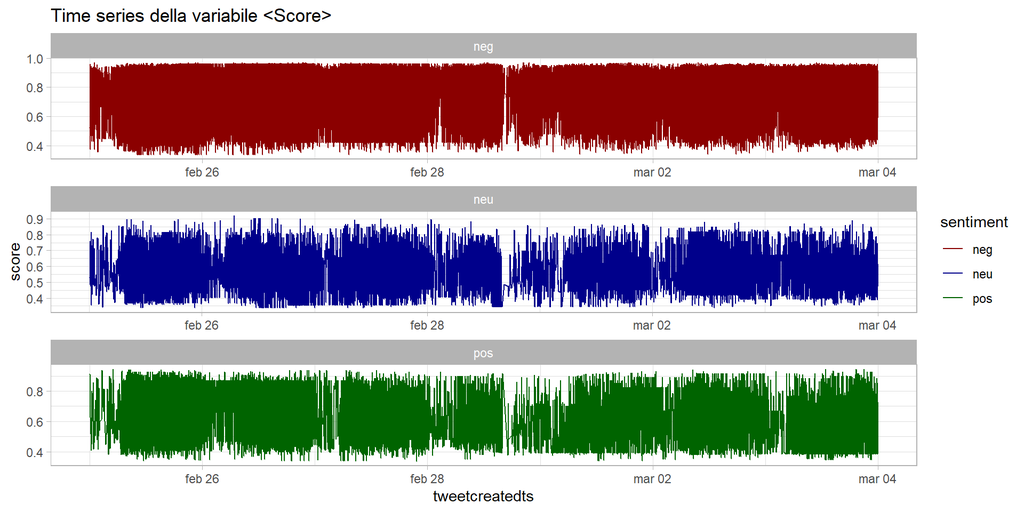

Osserviamo la loro distribuzione

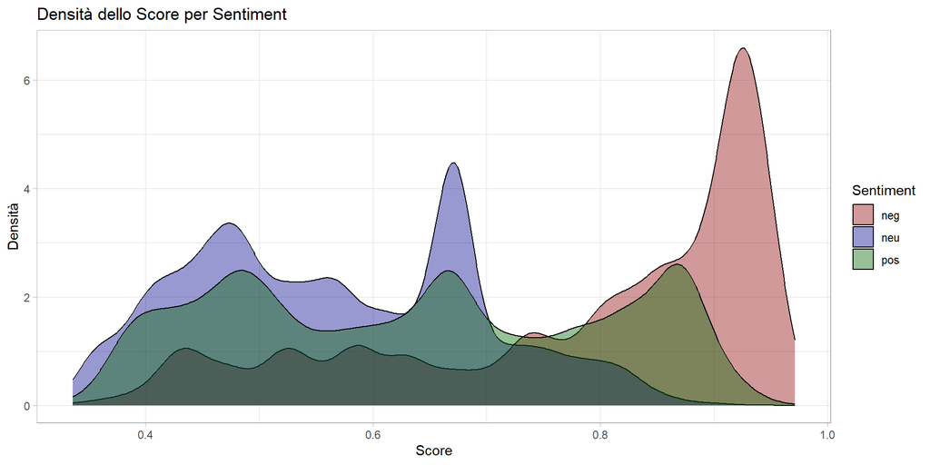

## Analisi della *Stazionarietà* e *Autocorrelazione* delle serie storiche

Sicuramente le serie non presentano forti Trend, né tantomeno forte Periodicità o Ciclicità dei dati. Per come si distribuiscono le serie molto probabilmente seguono una distribuzione **White Noise** e di **stazionarietà** rimanendo stabili intorno alla media e con la stessa variabilità nel tempo.

Per poter verificare ciò, utilizzeremo due test di ipotesi:

1. **Test di Ljung-Box**
   - *Scopo*: Verificare **l’autocorrelazione** residua in una serie temporale
   - *Ipotesi nulla (H₀)*: Non vi è autocorrelazione fino a un certo lag -> *white noise*
   - *Ipotesi alternativa (H₁)*: Vi è autocorrelazione fino a un certo lag
   - Conclusione:
     - Un *p-value* piccolo (< 0.05) suggerisce di rifiutare H₀, indicando che c’è autocorrelazione significativa.
     - Un *p-value* grande indica che non ci sono evidenze di autocorrelazione.
2. **Kwiatkowski-phillips-Schmidt-Shin (KPSS) Test**
   - *Scopo*: Verificare se una serie temporale è **stazionaria**.
   - *Ipotesi nulla (H₀)*: La serie è stazionaria.
   - *Ipotesi alternativa (H₁)*: La serie non è stazionaria
   - Conclusione:
     - Un *p-value* piccolo (ad esempio, < 0.05) suggerisce di rifiutare H₀, quindi la serie non è stazionaria e potrebbe necessitare differenziazione.
     - Un *p-value* grande non permette di rifiutare H₀, suggerendo che la serie è stazionaria.

Per la serie storica dello score negativo:

Score

KPSS Test

Ljung-Box Test

Negativo

```
test-statistic is: 73.8069
```

Non stazionario

```
p-value < 2.2e-16
```

Autocorrelazione presente

Neutrale

```
test-statistic is: 17.6576
```

Non stazionario

```
p-value < 2.2e-16
```

Autocorrelazione presente

Positivo

```
test-statistic is: 34.624
```

Non stazionario

```
p-value < 2.2e-16
```

Autocorrelazione presente

Dai risultati del test si evince che le serie **non sono stazionarie** e non seguono una distribuzione white noise quindi **presentano autocorrelazione** nei ritardi definiti. Questo risultato potrebbe sembrare correlato ma ricordiamo che *autocorrelazione non implica non-stazionarietà* così e viceversa in quanto la stazionarietà riguarda proprietà generali della serie nel tempo, mentre il test di Ljung-Box per l’autocorrelazione si concentra su pattern di dipendenza temporale osservando sotto-intervalli di lag.

Osserviamo se questa struttura della serie persiste anche se diminuiamo la frequenza di osservazione dei dati. In particolare concentriamoci nell’analizzare le serie a frequenze di 10 minuti, 30 minuti e 1 ora.

### Analisi con frequenza di **10 minuti**:

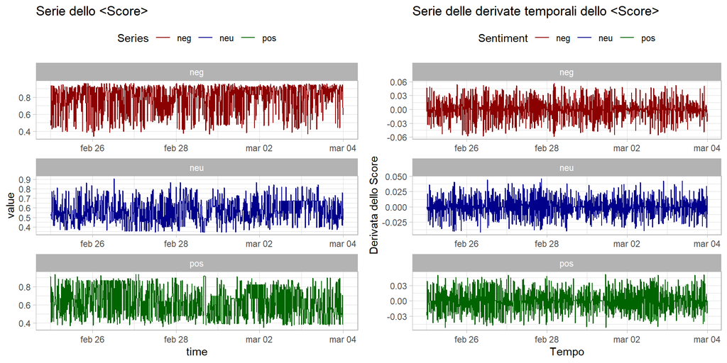

Osserviamo i risultati dei test sull’autocorrelazione e stazionarietà delle serie:

|  | KPSS Test | Ljung-Box Test |
| --- | --- | --- |
| **Serie dello Score** | test-statistic is: **1.6076** (N.S.) test-statistic is: **1.0155** (N.S.) test-statistic is: **1.5981** (N.S.) | p-value = **0.5361** (N.A.) p-value = **3.389e-06** (A.) p-value = **0.01512** (A.) |
| **Derivata dello Score** | test-statistic is: **0.0111** (S.) test-statistic is: **0.006** (S.) test-statistic is: **0.0068** (S.) | p-value < **2.2e-16** (A.) p-value < **2.2e-16** (A.) p-value < **2.2e-16** (A.) |

Notiamo che a questa frequenza la statistica test per l’ipotesi di stazionarietà per la serie priva di trasformazioni è scesa di molto ma rimane ancora più grande della soglia critica del 1%. Per quanto riguarda invece la serie delle derivate temporali, queste sono già stazionarie. Mentre a questo livello solo la serie dello score negativa diviene White Noise e perde quindi autocorrelazione nei ritardi.

Osserviamo l’andamento generale dello score a questa frequenza:

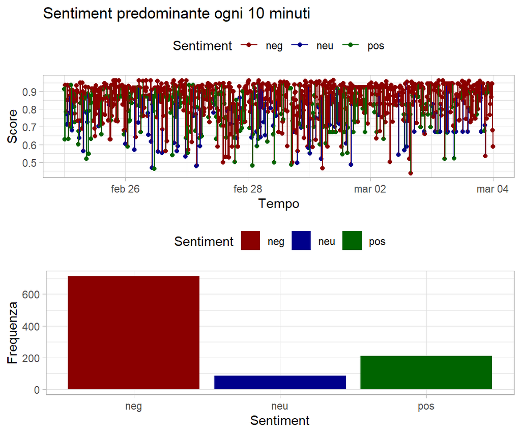

### Analisi con frequenza di **30 minuti**:

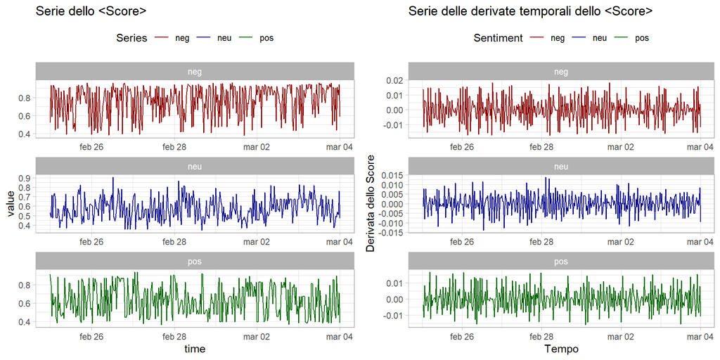

Osserviamo i risultati dei test:

| Score | KPSS Test | Ljung-Box Test |
| --- | --- | --- |
| **Serie dello Score** | test-statistic is: **0.7737** (N.S.) test-statistic is: **0.2137** (S.) test-statistic is: **0.2168** (S.) | p-value = **0.07077** (N.A.) p-value = **0.0007944** (A.) p-value = **0.357** (N.A.) |
| **Derivate dello Score** | test-statistic is: **0.0111** (S.) test-statistic is: **0.006** (S.) test-statistic is: **0.0068** (S.) | p-value < **2.2e-16** (A.) p-value = **3.563e-13** (A.) p-value = **1.984e-12** (A.) |

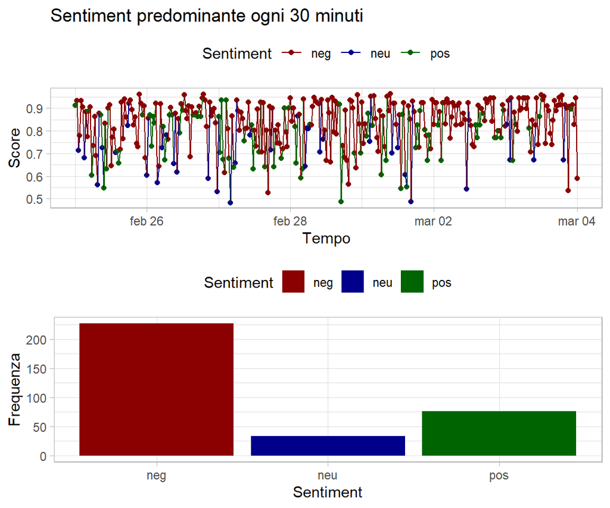

### Analisi con frequenza di **1 ora**:

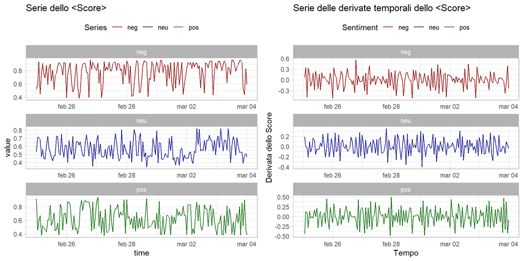

Osserviamo i risultati dei test:

| Score | KPSS Test | Ljung-Box Test |
| --- | --- | --- |
| **Serie dello Score** | test-statistic is: **0.3793** (S.) test-statistic is: **0.1504** (S.) test-statistic is: **0.1444** (S.) | p-value = **0.1761** (N.A.) p-value = **0.09925** (N.A.) p-value = **0.4608** (N.A.) |
| **Derivate dello Score** | test-statistic is: **0.0111** (S.) test-statistic is: **0.006** (S.) test-statistic is: **0.0068** (S.) | p-value = **2.32e-05** (A.) p-value = **4.77e-06** (A.) p-value = **1.427e-11** (A.) |

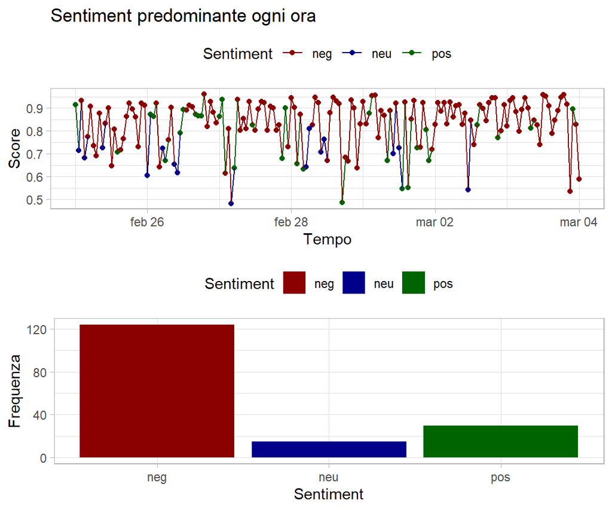

#### Riflessioni

Per quanto riguarda la serie dello Score, quello che si osserva è che man mano che aggreghiamo i dati ad una frequenza più bassa le serie tendono ad assumere distribuzione *white noise* così come anche la stazionarietà viene raggiunta da tutte le serie all’ultima frequenza. Invece le serie delle derivate temporali hanno sempre mostrato le medesime caratteristiche ossia stazionarietà e autocorrelazione a qualsiasi livello di frequenza si stessero osservando.

## Costruzione dei Modelli Statistici

### Non-seasonal ARIMA models

ARIMA è l’acronimo di AutoRegressive Integrated Moving Avarage, mette insieme il concetto della differenziazione con i modelli autoregressivi e media mobile.

$$y'_{t} = c + \phi_{1}y'_{t-1} + \dots + \phi_{p}y'_{t-p} +
\theta_{1}\varepsilon_{t-1} + \dots + \theta_{p}\varepsilon_{t-p}$$

In *backshift-notation* diventa:

$$(1 - \phi_{1}B - \dots - \phi_{p}B^{p})(1-B)^{d}y_{t} = c +
(1+\theta_{1}B+\dots+\theta_{q}B^{q})\varepsilon_{t}$$

Dove $y'_{t}$ è la serie differenziata (anche più di una volta), mentre i predittori sono i *lag* della serie e i *lag-errors* sempre della serie. Questa struttura prende il nome di **ARIMA(p, d, q)** **Model** dove

- *p* = ordine della parte autoregressiva
- *d* = gradi di differenziazione
- *q* = ordine della media mobile

Molti modelli fra i più conosciuti sono solo un caso specifico del modello ARIMA(p, d, q) infatti

- White Noise = ARIMA(0, 0 , 0)
- Random Walk = ARIMA(0, 1, 0)
- Autoregressione = ARIMA(p, 0, 0)
- Media Mobile = ARIMA(0, 0 , q)

Stimiamo un modello ARIMA(p, d, q) per le singole serie dello score e delle derivate temporali dello score.

```
## # A tibble: 9 × 5
##   Serie     ARIMA      AIC   AICc    BIC
##   <chr>     <chr>    <dbl>  <dbl>  <dbl>
## 1 10min_NEG (0,1,1)  -736.  -736.  -726.
## 2 10min_NEU (0,1,1) -1430. -1430. -1420.
## 3 10min_POS (0,1,1)  -829.  -829.  -819.
## 4 30min_NEG (0,1,4)  -232.  -232.  -213.
## 5 30min_NEU (1,0,1)  -502.  -502.  -487.
## 6 30min_POS (1,0,0)  -279.  -279.  -267.
## 7 1h_NEG    (1,0,1)  -132.  -132.  -120.
## 8 1h_NEU    (1,0,1)  -252.  -251.  -239.
## 9 1h_POS    (2,0,0)  -137.  -137.  -125.
```

```
## # A tibble: 9 × 5
##   Serie     ARIMA      AIC   AICc    BIC
##   <chr>     <chr>    <dbl>  <dbl>  <dbl>
## 1 10min_NEG (0,0,1) -5378. -5378. -5368.
## 2 10min_NEU (0,0,1) -6072. -6072. -6062.
## 3 10min_POS (0,0,1) -5471. -5471. -5461.
## 4 30min_NEG (0,0,4) -2518. -2518. -2499.
## 5 30min_NEU (0,0,1) -2780. -2780. -2772.
## 6 30min_POS (1,0,1) -2557. -2557. -2546.
## 7 1h_NEG    (1,0,2)  -126.  -126.  -114.
## 8 1h_NEU    (0,0,1)  -246.  -246.  -240.
## 9 1h_POS    (0,0,1)  -128.  -128.  -122.
```

#### Serie storica dello Score

Osserviamo come i modelli ARIMA hanno fittato sui dati:

- **Frequenza di 10 minuti**

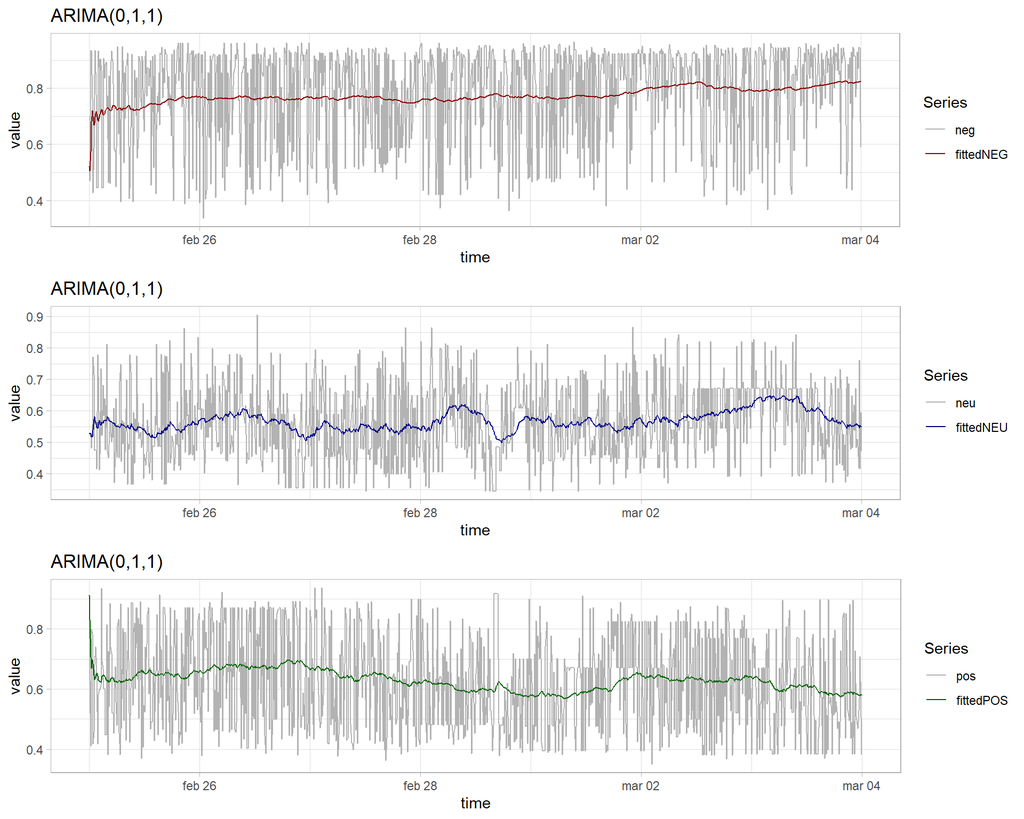

- **Frequenza di 30 minuti**

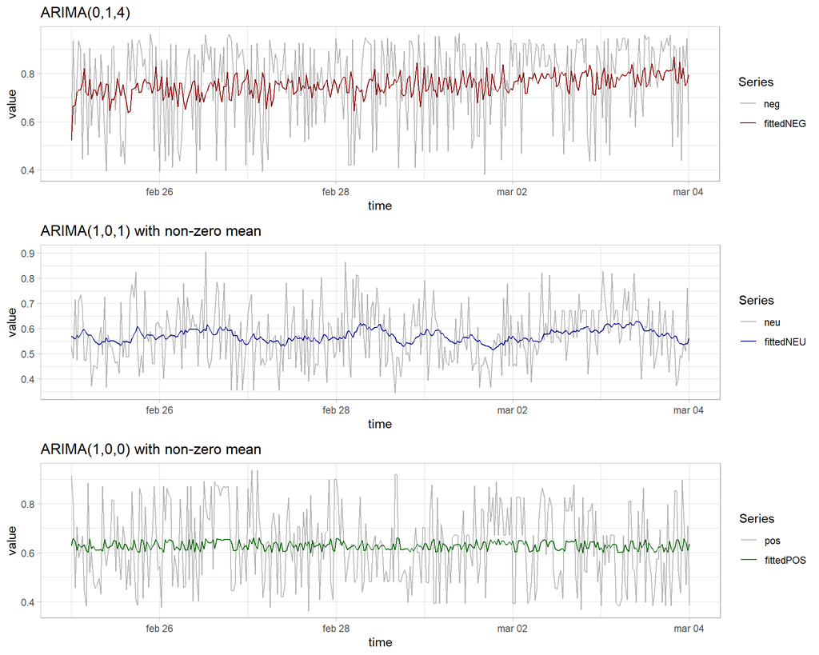

- **Frequenza di 1 ora**

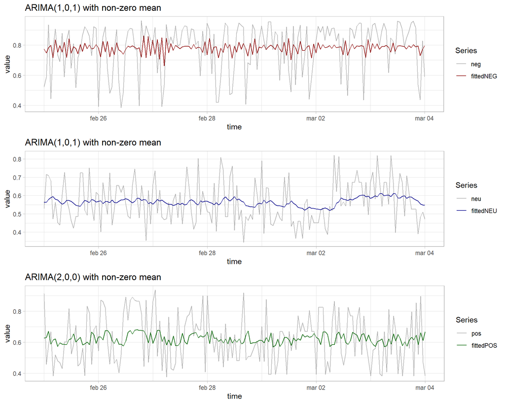

#### Serie storiche delle derivate temporali dello Score

- **Frequenza di 10 minuti**

[figure not shown]

- **Frequenza di 30 minuti**

[figure not shown]

- **Frequenza di 1 ora**

[figure not shown]

### Auto-Regressive Neural Network

#### Serie storiche dello Score

- **Frequenza di 10 minuti**

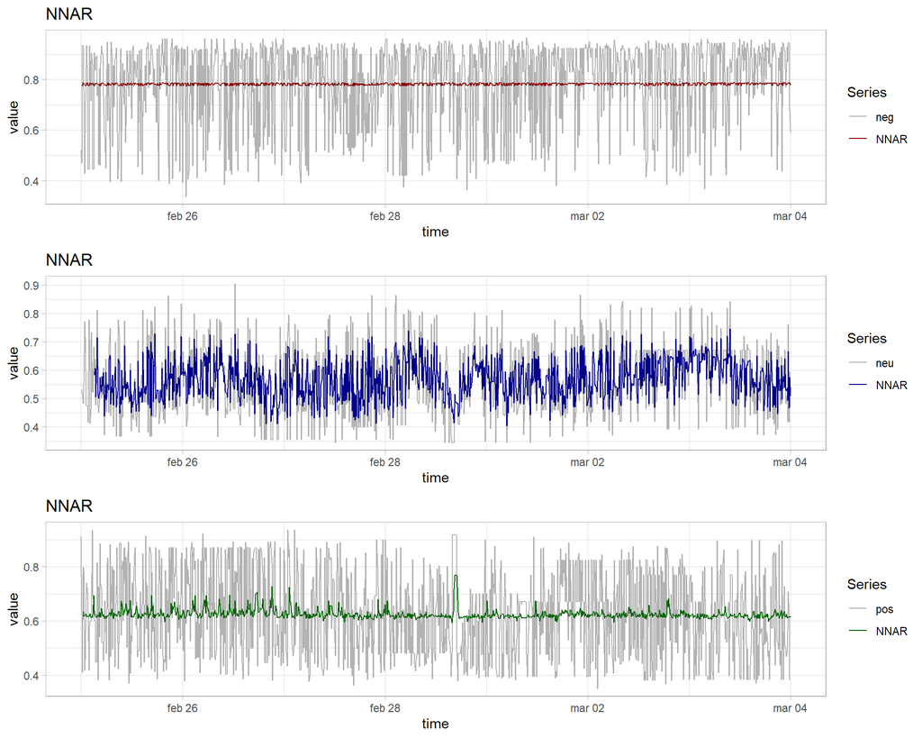

- **Frequenza di 30 minuti**

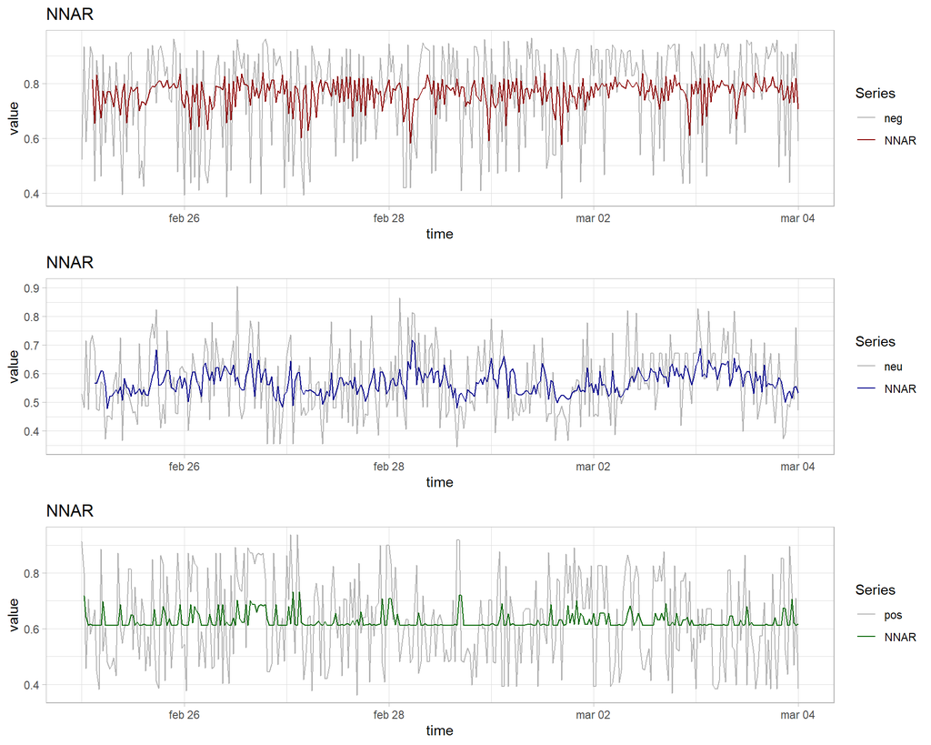

- **Frequenza di 1 ora**

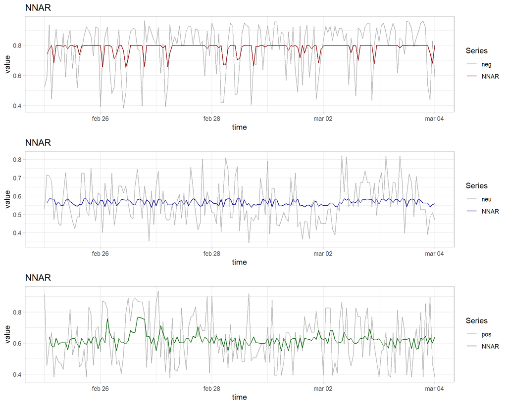

#### Serie storiche delle derivate temporali dello Score

- **Frequenza di 10 minuti**

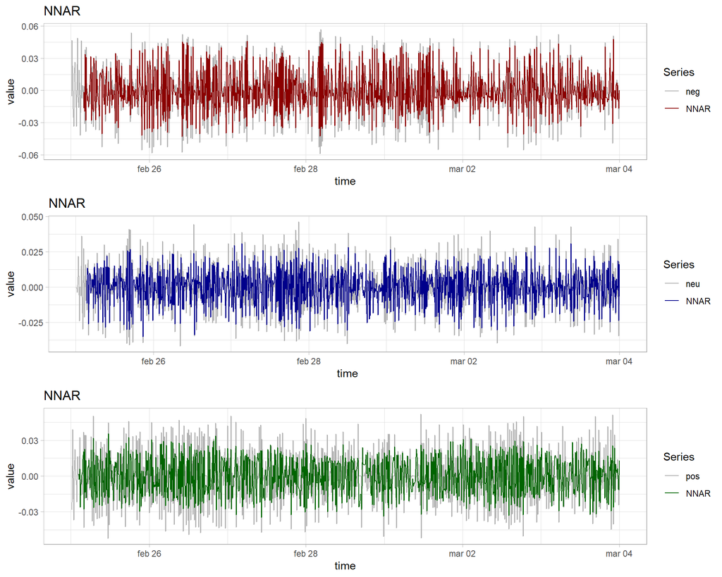

- **Frequenza di 30 minuti**

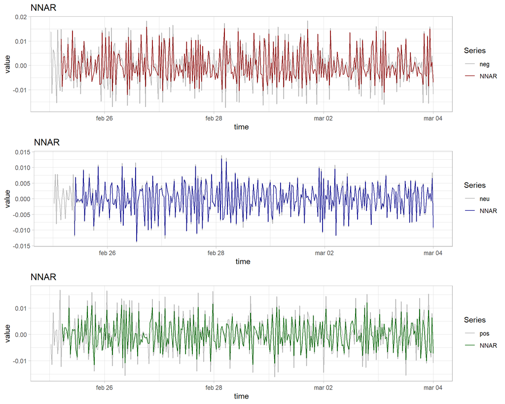

- **Frequenza di 1 ora**

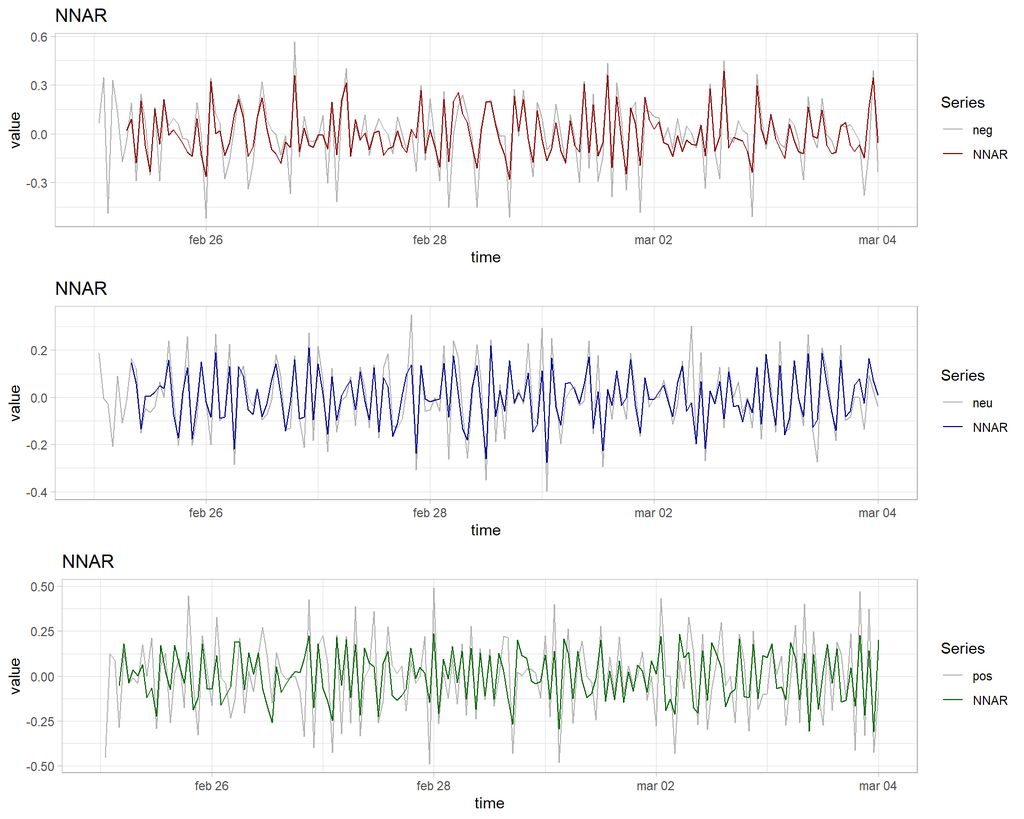

## Valutazione Modelli Statistici

### Evaluation dei modelli per le serie storiche dello Score

Osserviamo i risultati ottenuti dai modelli:

```
## # A tibble: 18 × 5
##      RMSE    MAE Serie      Model  Stage
##     <dbl>  <dbl> <chr>      <chr>  <chr>
##  1 0.118  0.104  score10neg ARIMA  Test Set
##  2 0.130  0.118  score10neg NNETAR Test Set
##  3 0.107  0.0925 score10neu ARIMA  Test Set
##  4 0.103  0.0868 score10neu NNETAR Test Set
##  5 0.124  0.110  score10pos ARIMA  Test Set
##  6 0.137  0.120  score10pos NNETAR Test Set
##  7 0.176  0.148  score1hneg ARIMA  Test Set
##  8 0.177  0.144  score1hneg NNETAR Test Set
##  9 0.108  0.0965 score1hneu ARIMA  Test Set
## 10 0.0977 0.0872 score1hneu NNETAR Test Set
## 11 0.181  0.161  score1hpos ARIMA  Test Set
## 12 0.196  0.177  score1hpos NNETAR Test Set
## 13 0.202  0.171  score30neg ARIMA  Test Set
## 14 0.198  0.172  score30neg NNETAR Test Set
## 15 0.120  0.104  score30neu ARIMA  Test Set
## 16 0.120  0.110  score30neu NNETAR Test Set
## 17 0.180  0.163  score30pos ARIMA  Test Set
## 18 0.182  0.165  score30pos NNETAR Test Set
```

Osserviamo i migliori modelli sul **Test Set**

```
## # A tibble: 9 × 5
##     RMSE    MAE Serie      Model  Stage
##    <dbl>  <dbl> <chr>      <chr>  <chr>
## 1 0.118  0.104  score10neg ARIMA  Test Set
## 2 0.103  0.0868 score10neu NNETAR Test Set
## 3 0.124  0.110  score10pos ARIMA  Test Set
## 4 0.177  0.144  score1hneg NNETAR Test Set
## 5 0.0977 0.0872 score1hneu NNETAR Test Set
## 6 0.181  0.161  score1hpos ARIMA  Test Set
## 7 0.202  0.171  score30neg ARIMA  Test Set
## 8 0.120  0.104  score30neu ARIMA  Test Set
## 9 0.180  0.163  score30pos ARIMA  Test Set
```

Osserviamo i plot

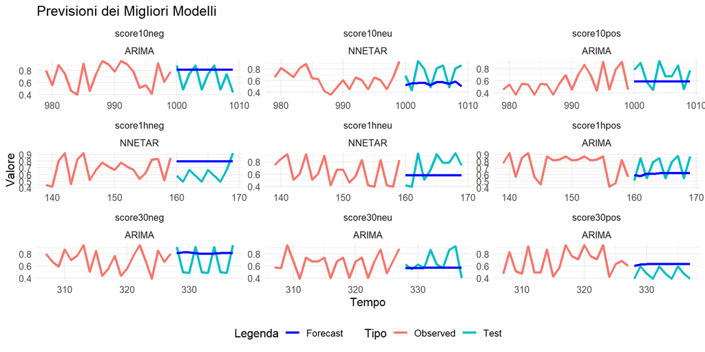

### Evaluation dei modelli per serie storiche delle derivate temporali

```
## # A tibble: 18 × 5
##       RMSE     MAE Serie      Model  Stage
##      <dbl>   <dbl> <chr>      <chr>  <chr>
##  1 0.0115  0.00897 deriv10neg ARIMA  Test Set
##  2 0.0127  0.0104  deriv10neg NNETAR Test Set
##  3 0.0186  0.0145  deriv10neu ARIMA  Test Set
##  4 0.0170  0.0135  deriv10neu NNETAR Test Set
##  5 0.0127  0.00970 deriv10pos ARIMA  Test Set
##  6 0.0123  0.00955 deriv10pos NNETAR Test Set
##  7 0.194   0.135   deriv1hneg ARIMA  Test Set
##  8 0.236   0.188   deriv1hneg NNETAR Test Set
##  9 0.108   0.0845  deriv1hneu ARIMA  Test Set
## 10 0.133   0.112   deriv1hneu NNETAR Test Set
## 11 0.303   0.260   deriv1hpos ARIMA  Test Set
## 12 0.393   0.342   deriv1hpos NNETAR Test Set
## 13 0.0112  0.00989 deriv30neg ARIMA  Test Set
## 14 0.0124  0.0105  deriv30neg NNETAR Test Set
## 15 0.00489 0.00382 deriv30neu ARIMA  Test Set
## 16 0.00468 0.00384 deriv30neu NNETAR Test Set
## 17 0.00855 0.00717 deriv30pos ARIMA  Test Set
## 18 0.00739 0.00604 deriv30pos NNETAR Test Set
```

```
## # A tibble: 9 × 5
##      RMSE     MAE Serie      Model  Stage
##     <dbl>   <dbl> <chr>      <chr>  <chr>
## 1 0.0115  0.00897 deriv10neg ARIMA  Test Set
## 2 0.0170  0.0135  deriv10neu NNETAR Test Set
## 3 0.0123  0.00955 deriv10pos NNETAR Test Set
## 4 0.194   0.135   deriv1hneg ARIMA  Test Set
## 5 0.108   0.0845  deriv1hneu ARIMA  Test Set
## 6 0.303   0.260   deriv1hpos ARIMA  Test Set
## 7 0.0112  0.00989 deriv30neg ARIMA  Test Set
## 8 0.00489 0.00382 deriv30neu ARIMA  Test Set
## 9 0.00739 0.00604 deriv30pos NNETAR Test Set
```

Osserviamo i plot:

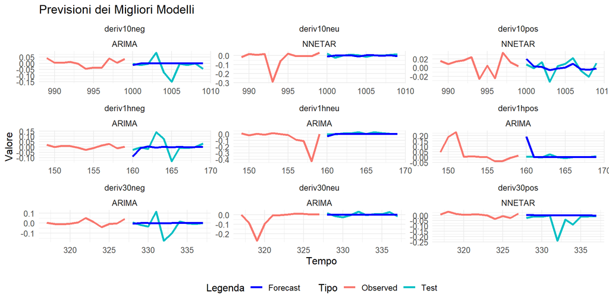